# 3 - Data Manipulation, Aggregation, Summary

Wendy Wagner

2025-03-15

# 1. Introduction

# 2. Getting Started

# 3. Data Cleaning

Let us load a larger data set and begin with some basic data manipulation and analysis:

```r
mtcars <- mtcars # Exists in baseR
names(mtcars)
```

```
##  [1] "mpg"  "cyl"  "disp" "hp"   "drat" "wt"   "qsec" "vs"   "am"   "gear"
## [11] "carb"
```

```r
summary(mtcars)
```

```
##       mpg             cyl             disp             hp
##  Min.   :10.40   Min.   :4.000   Min.   :-99.0   Min.   : 52.0
##  1st Qu.:15.43   1st Qu.:4.000   1st Qu.:120.2   1st Qu.: 96.5
##  Median :19.20   Median :6.000   Median :167.6   Median :123.0
##  Mean   :20.09   Mean   :6.188   Mean   :212.9   Mean   :146.7
##  3rd Qu.:22.80   3rd Qu.:8.000   3rd Qu.:307.5   3rd Qu.:180.0
##  Max.   :33.90   Max.   :8.000   Max.   :460.0   Max.   :335.0
##       drat             wt             qsec             vs
##  Min.   :2.760   Min.   :1.513   Min.   :14.50   Min.   :0.0000
##  1st Qu.:3.080   1st Qu.:2.581   1st Qu.:16.89   1st Qu.:0.0000
##  Median :3.695   Median :3.325   Median :17.71   Median :0.0000
##  Mean   :3.597   Mean   :3.217   Mean   :17.85   Mean   :0.4375
##  3rd Qu.:3.920   3rd Qu.:3.610   3rd Qu.:18.90   3rd Qu.:1.0000
##  Max.   :4.930   Max.   :5.424   Max.   :22.90   Max.   :1.0000
##        am              gear            carb
##  Min.   :0.0000   Min.   :3.000   Min.   :1.000
##  1st Qu.:0.0000   1st Qu.:3.000   1st Qu.:2.000
##  Median :0.0000   Median :4.000   Median :2.000
##  Mean   :0.4062   Mean   :3.688   Mean   :2.812
##  3rd Qu.:1.0000   3rd Qu.:4.000   3rd Qu.:4.000
##  Max.   :1.0000   Max.   :5.000   Max.   :8.000
```

## 3.1 Declare Missing Values

Missing data represents data that is either unavailable, or irrelevant to the purposes of our study. Some cells in our data may be system-missing (completely empty and usually denoted as NA). Some variables have user-missing data, i.e. values we wish to ignore. It is important to deal with such data because it can affect our statistical calculation.

From the above output, disp stands out with a minimum value of -99. Often values such as 99, -99, 999, etc are used as indicators of missingness. We want to **recode** this as NA. Both baseR with if_else statements as well as the na_if() function from the `dplyr or tidyverse package` can be useful for this. Let’s assume we know that -99 here stands for a missing value, we can write the following command: please assign the variable `disp` the value NA IF the value is -99, but IF NOT equal to -99 keep the value it has.

```r
# Using baseR
mtcars$disp <- ifelse(mtcars$disp==-99, NA, mtcars$disp)
```

Another way to achieve the same thing is by using `[]` square brackets to denote a condition: assign `disp` the value NA IF `disp` equals -99.

```r
# Using baseR
mtcars$disp[mtcars$disp==-99] <- NA
```

Finally, we can use the `tidyverse` package that includes a suite of useful tools for data manipulation including the so called `pip` operate %>%

```r
#install.packages("tidyverse") # Install if not yet installed
library(tidyverse) # call at beginning of every session
mtcars <- mtcars %>%
  mutate(disp = na_if(disp, -99))
```

## 3.2 Levels of Measurement

Reminder, we generally tend to work with three levels of measurement:

- Nominal (Factor) Variables - Categorical data, values represent categories, or qualities. Their order and size (of the values) are meaningless.
- Ordinal (Ordered) Variables - Categorical data, the order of the variables is important, but their size is not.
- Continuous Variables - Numeric data. Values represent numbers. Both the order and size of the values are meaningful. We will learn about the distinction between interval and ratio variables (both continuous) later on.

It is important to properly define the level of measurement of all variables of interest, because that will determine which statistical models we can use for each variable, how each variable should be used within each statistical model and how R should treat each variable. First, we can use the class() function to check how R currently stores each variable:

It seems that many of these variables in mtcars are not actually continuous but instead binary or factor variables. vs and am have a minimum value of zero and a maximum of one, indicating a binary factor variable. cyl, gear, and carb seem to be ordered whole numbers.

```r
class(mtcars$mpg)
```

```
## [1] "numeric"
```

```r
class(mtcars$disp)
```

```
## [1] "numeric"
```

```r
class(mtcars$vs)
```

```
## [1] "numeric"
```

```r
class(mtcars$am)
```

```
## [1] "numeric"
```

```r
# Once again, we can use the map() function from the dplyr package to quickly review the class of all variables in our dataset:
map(mtcars, class)
```

```
## $mpg
## [1] "numeric"
##
## $cyl
## [1] "numeric"
##
## $disp
## [1] "numeric"
##
## $hp
## [1] "numeric"
##
## $drat
## [1] "numeric"
##
## $wt
## [1] "numeric"
##
## $qsec
## [1] "numeric"
##
## $vs
## [1] "numeric"
##
## $am
## [1] "numeric"
##
## $gear
## [1] "numeric"
##
## $carb
## [1] "numeric"
```

Yet, we see all these variables are incorrectly displayed as numeric (continuous). Some of the variables are not stored correctly and we need to declare to R what the correct level of measurement is for these variables, and sometimes how to label the values within a variable.

```r
# Recoding class individually and assigning labels
table(mtcars$am)
```

```
##
##  0  1
## 19 13
```

```r
mtcars$am <- factor(mtcars$am, # the variable
levels = c(0:1), # the values within the variable
labels = c("automatic","manual"))
```

Note the use of two vectors within this function - one to specify the levels (numeric values) of the variable, and one to specify how to label these values.

Now let’s check if this worked out:

```r
class(mtcars$am)
```

```
## [1] "factor"
```

```r
table(mtcars$am)
```

```
##
## automatic    manual
##        19        13
```

Much Better! We can do the same thing for declaring ordinal variables, using the ordered() function.

```r
table(mtcars$cyl)
```

```
##
##  4  6  8
## 11  7 14
```

```r
mtcars$cyl <- ordered(mtcars$cyl,
levels = c(4, 6, 8),
labels= c("4 Cylinder","6 Cylinder","8 Cylinder"))
table(mtcars$cyl)
```

```
##
## 4 Cylinder 6 Cylinder 8 Cylinder
##         11          7         14
```

We can also do all steps in one go:

```r
# Recode all in one go
mtcars2 <- within(mtcars, {
   vs <- factor(vs, labels = c("V", "S"))
   am <- factor(am, labels = c("automatic", "manual"))
   cyl  <- ordered(cyl)
   gear <- ordered(gear)
   carb <- ordered(carb)
})
```

# 4. Summary Statistics

When using various summary statistics, you as the researcher must know which statistic is an appropriate metric in which case. As a refresher, we can calculate the mean, media, variance, and standard deviation, as well as minimum and maximum only for numerical or continuous data, and only if there are ‘real’ distances between values. For example, it makes sense to calculate an average salary but not an average gender. In the case of nominal variables, such as gender or favorite ice cream flavor, we can provide counts and frequencies but no meaningful mean, median or standard deviation.

You already saw one way of representing distributions in the data through baseR plots using the `iris` data set. Using the mtcars dataset, we can looks at some univariate summary statistics. Note that the command `na.rm=TRUE` tells R to calculate the statistic also if there are missing values, by dropping those observations.

```r
dim(mtcars2)
```

```
## [1] 32 11
```

```r
summary(mtcars2)
```

```
##       mpg                cyl          disp             hp
##  Min.   :10.40   4 Cylinder:11   Min.   : 71.1   Min.   : 52.0
##  1st Qu.:15.43   6 Cylinder: 7   1st Qu.:120.7   1st Qu.: 96.5
##  Median :19.20   8 Cylinder:14   Median :167.6   Median :123.0
##  Mean   :20.09                   Mean   :222.9   Mean   :146.7
##  3rd Qu.:22.80                   3rd Qu.:311.0   3rd Qu.:180.0
##  Max.   :33.90                   Max.   :460.0   Max.   :335.0
##                                  NA's   :1
##       drat             wt             qsec       vs             am     gear
##  Min.   :2.760   Min.   :1.513   Min.   :14.50   V:18   automatic:19   3:15
##  1st Qu.:3.080   1st Qu.:2.581   1st Qu.:16.89   S:14   manual   :13   4:12
##  Median :3.695   Median :3.325   Median :17.71                         5: 5
##  Mean   :3.597   Mean   :3.217   Mean   :17.85
##  3rd Qu.:3.920   3rd Qu.:3.610   3rd Qu.:18.90
##  Max.   :4.930   Max.   :5.424   Max.   :22.90
##
##  carb
##  1: 7
##  2:10
##  3: 3
##  4:10
##  6: 1
##  8: 1
##
```

```r
mean(mtcars2$mpg, na.rm=T)
```

```
## [1] 20.09062
```

```r
median(mtcars2$mpg, na.rm=T)
```

```
## [1] 19.2
```

```r
sd(mtcars2$mpg, na.rm=T)
```

```
## [1] 6.026948
```

For nominal or categorical variables (i.e. those coded as ordered or factor), we rely on frequency tables and plots to understand the distribution of a specific variable:

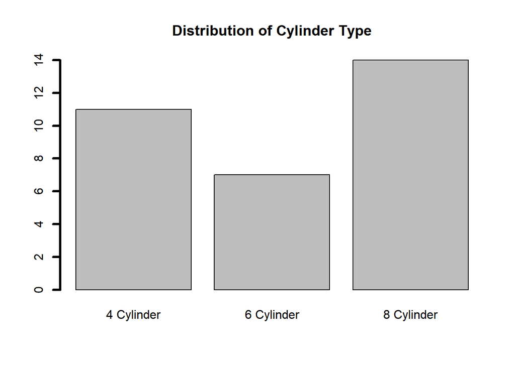

```r
plot(mtcars2$cyl, lwd = 3,
     main = "Distribution of Cylinder Type") # Using baseR
```

- ‘Univariate’ means describing or summarizing the distribution of one variable at a time.

# 5. Data Manipulation

Frequently, we seek to make our data more informative by recoding categories or assigning labels, or simply renaming variable names to be more easily understood. We can use the tools in the `tidyverse` package to manipulate our data in a variety of ways: rename variables, recode to create new variables, subset data and observations.

- Note: Make sure to never overwrite existing variables, for example when recoding a variable. It is a best practice, to always maintain the integrity of the original data to avoid loosing information. Aggregating a variable cannot be reversed once the data is aggregated and going back will require to download and import the original data once more. It is known to happen that researchers conduct a survey, aggregate information and accidentally saving the new data under the same name - this may result in hundreds of hours and thousands of dollars lost.

## 5.1 Renaming

We can utilize both base R and tidyverse functions to recode the names of variables but make sure you are aware when you replace existing names. Different from recoding, names of variables can easily be changed back. Here we are saying to R, please take the name of the variable IF the name is equal to ‘cyl’ and call it now ‘cylinder’. Note that in base R, we refer to variable names with quotation marks. The tidyverse function might at first seem longer, but it benefits from making quotation signs when working with variable names unnecessary and from the ability to easily recode many variable names in one go, plus being able to combine it in one step with other operations!

```r
names(mtcars2)[names(mtcars2)=="cyl"]<-"cylinder" # base R using IF brackets
mtcars2 <- mtcars2 %>%
  rename(cyl=cylinder) # tidyverse using pipe
```

This may be a good opportunity to visit the ‘documentation’ for the tidyverse package by calling `?tidyverse` and `?dplyr` or any of its sub-functions”. Try in your R console:

```r
#arrange(), filter(), mutate(), reframe(), select(), slice(), summarise()
?tidyverse
?rename
?filter
?summarise
```

## 5.2 Recoding

One common operation is recoding a continuous numerical variable into categories, for example, recoding household income into high/medium/low income categories. Here are three useful ways to do something like this: (1) nested if statements and coding with conditions, (2) base R and the cut function, and (3) tidyverse and case_when.

```r
# 1 Recode with Base R and ifelse
mydata$newvariable <- <- ifelse(mydata$num < 45, "Low",
                               ifelse(mydata$num <= 55, "Medium", "High"))

# 2 Recode with Base R and cut
mydata$newvariable <- cut(mydata$num,
                         breaks = c(-Inf, 45, 55, Inf),
                         labels = c("Low", "Medium", "High"),
                         right = TRUE)

# 3 Recode with Tidyverse and case_when
mydata <- mydata %>%
  mutate(category = case_when(
    num < 45 ~ "Low",
    num >= 45 & num <= 55 ~ "Medium",
    num > 55 ~ "High"
  ))

# For information use
?case_when
```

# 6. Aggregating Data

Let’s begin by loading Bad Driver Data. Again, we will be using both base R and tidyverse to achieve this. Install the packages “fivethirtyeight” and “ISLR” if needed, we will use data included in this package.

```r
# Install if necessary
library(tidyverse)
library(fivethirtyeight)
library(ISLR)

mydata <- fivethirtyeight::bad_drivers

mean(mydata$num_drivers) # Mean calculation with base R
```

```
## [1] 15.7902
```

```r
mydata$num_drivers %>% mean() # Mean with tidyverse and pipe %>%
```

```
## [1] 15.7902
```

## 6.1 Group Aggregation

Sometimes we are interested in calculating summary statistics grouped by some variable (i.e. gender, race, country, county). Or at times we are interested in aggregating the data by some criteria and saving the resulting aggregated dataset.

Load the cars data and recode the variable origin as a “factor” variable with the following labels:

```r
cars <- ISLR::Auto
cars$origin <- factor(cars$origin,
                      levels = c(1:3),
                      labels=c("American", "European", "Japanese"))
```

To create an aggregated data.frame of the mean of acceleration time by origin:

```r
mycars <- aggregate(acceleration ~ origin,
                    data = cars,
                    FUN = mean, na.rm = T)
mycars
```

```
##     origin acceleration
## 1 American     14.99020
## 2 European     16.79412
## 3 Japanese     16.17215
```

Functions can include any of the R calculations such as mean() , median() , sd() , var() , max() , min() , etc.

You can also aggregate a number of variables by a number of other variables. The downside of this approach is that we will have to manually rename the columns after aggregation.

```r
mycars <- aggregate(x = list(cars$acceleration,cars$horsepower,cars$weight),
                    by = list(cars$year,cars$origin),
                    FUN = mean, na.rm = T)
colnames(mycars) <- c("year","origin","acceleration","horsepower","weight")
```

Car Measures by Origin & Year:

```r
mycars
```

```
##    year   origin acceleration horsepower   weight
## 1    70 American     11.97727  166.95455 3716.500
## 2    71 American     14.34211  119.84211 3472.947
## 3    72 American     14.05556  138.77778 3682.667
## 4    73 American     13.62069  146.62069 3821.448
## 5    74 American     15.89286  112.14286 3548.214
## 6    75 American     16.35000  108.70000 3533.200
## 7    76 American     15.78636  110.50000 3405.409
## 8    77 American     15.23889  118.38889 3422.000
## 9    78 American     15.54545  107.27273 3141.136
## 10   79 American     15.24348  109.43478 3210.217
## 11   80 American     17.21667   88.83333 2808.667
## 12   81 American     16.05385   84.53846 2695.000
## 13   82 American     16.46842   86.94737 2616.842
## 14   70 European     16.50000   86.20000 2309.200
```

[output cut: 25 more lines]

Here is the same operation in tidyverse:

```r
mycars <- cars %>%
  group_by(origin) %>%
  summarise(acceleration = mean(acceleration))
```

What we did we here was specify using the cars data.frame, then we asked R to group the data by origin, and then create a new variable containing the mean of acceleration. This is also easier for our previous example of summarizing a number of variables by a number of other variables. Note that we can specify two or even more grouping variables. In grouping, R preserves all unique combinations of the chosen grouping variables, so for example, we can ‘aggregate’ a dataset of many cars over many years to a dataset that contains only one row per brand and year, essentially aggregating the other information in the dataset. Here, we are calculating the average weight, acceleration and horsepower per origin-year. `View()` this data before and after the operation to see what changed.

```r
mycars <- cars %>%
  group_by(year, origin) %>%
  summarise(acceleration = mean(acceleration),
            horsepower = mean(horsepower),
            weight = mean(weight))
```

This is even more convenient when you want to estimate more than one measure. For instance:

```r
mycars <- cars %>%
group_by(year) %>%
group_by(origin, add = T) %>%
summarise(`Acceleration (Mean)` = mean(acceleration),
`Acceleration (SD)` = sd(acceleration),
`Horse‐Power (Mean)` = mean(horsepower),
`Horse‐Power (SD)` = sd(horsepower),
`Weight (Mean)` = mean(weight),
`Weight (SD)` = sd(weight))
```

Try these out and see what happens. Each time in this exercise, we are overwriting the dataframe “mycars”. You can also choose to save each iteration as an individual new dataframe (if you want to keep them). Once you are done with this operation, save the aggregated dataframe as a new CSV data file.

```r
write.csv(mycars, "mycars_aggregate.csv", row.names = F) # Save with a different name than any initial datasets, NEVER overwrite original data
```

# 7. Merging Data

## 7.1 Appending Data

One situation in which you need to merge data would involve appending rows from one dataframe to another dataframe. Appending means simply that both datasets have the same variables for different subsets of the data, and you simply want to attach the rows to the end of the other dataset (a copy paste into another excel if you will so).

Let’s say our cars dataset above is split into two datasets, one with American cars, and one with non-American cars. We then use the command `rbind` to attach one dataset to the other.

```r
american <- read.csv("american.csv")
nonamerican <- read.csv("nonamerican.csv")

mydata <- rbind(american, nonamerican)
```

This approach only works when the columns are exactly the same. A better alternative is the tidyverse bind_rows() :

```r
mydata <- bind_rows(american, nonamerican)
```

This can deal with unequal columns.

## 7.2 Merging on Variables

```r
blame <- read.csv("blame.csv")
notblame <- read.csv("notblame.csv")
```

To merge the two files together we use merge() and by = to specify the id variable:

```r
mydata <- merge(blame, notblame, by = "state")
head(mydata)
```

```
##        state num_drivers.x perc_speeding perc_alcohol insurance_premiums.x
## 1    Alabama          18.8            39           30               784.55
## 2     Alaska          18.1            41           25              1053.48
## 3    Arizona          18.6            35           28               899.47
## 4   Arkansas          22.4            18           26               827.34
## 5 California          12.0            35           28               878.41
## 6   Colorado          13.6            37           28               835.50
##   losses.x num_drivers.y perc_not_distracted perc_no_previous
## 1   145.08          18.8                  96               80
## 2   133.93          18.1                  90               94
## 3   110.35          18.6                  84               96
## 4   142.39          22.4                  94               95
## 5   165.63          12.0                  91               89
## 6   139.91          13.6                  79               95
##   insurance_premiums.y losses.y
## 1               784.55   145.08
## 2              1053.48   133.93
## 3               899.47   110.35
## 4               827.34   142.39
## 5               878.41   165.63
## 6               835.50   139.91
```

Here we assume that the variable “state” exists in both datasets and identifies a unique row in data1 and data2. Then we “match” a row in data1 to a row in data2. The resulting new dataset mydata now includes all columns in both matched datasets.

But what happens if the two files do not share all observations? In other words, some IDs appear in one dataset but not in the other dataset?

- Merge and maintain all observations
- Merge and only maintain observations in the first (left) dataset

Maintain all observations in both datasets:

```r
mydata <- merge(blame, notblame, by="state", all=T)
```

Maintain only observations of the first dataset means that the new dataset should have the same number of rows as the first (left) dataset. If you suddenly see more rows appear, this means that you probbaly have some rows in the left file that get matched multiple times (are not unique).

```r
mydata <- merge(blame, notblame, by="state", all.x=T)
mydata <- left_join(blame, notblame, by="state")
```

In many cases you need more than one variable to identify rows uniquely in both datasets. For example, we need “state” and “year” to match two datsets. We have both variables in each dataset, named the same. The resulting dataframe with be build on “state” and “year” plus all variables of either datset. This is a function that you will find yourself using frequently, make sure the merge columns ‘match’ properly: variables you merge on are the same ‘class’, the spelling of names is identical, and confirm correct merging after your operation. For example, a left_join should never return more observations than your left or first dataset:

```r
mydata <- left_join(blame, notblame, by=c("state"))
```

Should something go wrong - and it will - in the process of merging, you can utilize set logic to assess overlap, union, and intersection of lists of values, to identify issues.

```r
unique(mydata$state)
```

```
##  [1] "Alabama"              "Alaska"               "Arizona"
##  [4] "Arkansas"             "California"           "Colorado"
##  [7] "Connecticut"          "Delaware"             "District of Columbia"
## [10] "Florida"              "Georgia"              "Hawaii"
## [13] "Idaho"                "Illinois"             "Indiana"
## [16] "Iowa"                 "Kansas"               "Kentucky"
## [19] "Louisiana"            "Maine"                "Maryland"
## [22] "Massachusetts"        "Michigan"             "Minnesota"
## [25] "Mississippi"          "Missouri"             "Montana"
## [28] "Nebraska"             "Nevada"               "New Hampshire"
## [31] "New Jersey"           "New Mexico"           "New York"
## [34] "North Carolina"       "North Dakota"         "Ohio"
## [37] "Oklahoma"             "Oregon"               "Pennsylvania"
## [40] "Rhode Island"         "South Carolina"       "South Dakota"
## [43] "Tennessee"            "Texas"                "Utah"
## [46] "Vermont"              "Virginia"             "Washington"
## [49] "West Virginia"        "Wisconsin"            "Wyoming"
```

```r
unique(blame$state)
```

```
##  [1] "Alabama"              "Alaska"               "Arizona"
##  [4] "Arkansas"             "California"           "Colorado"
##  [7] "Connecticut"          "Delaware"             "District of Columbia"
## [10] "Florida"              "Georgia"              "Hawaii"
## [13] "Idaho"                "Illinois"             "Indiana"
## [16] "Iowa"                 "Kansas"               "Kentucky"
## [19] "Louisiana"            "Maine"                "Maryland"
## [22] "Massachusetts"        "Michigan"             "Minnesota"
## [25] "Mississippi"          "Missouri"             "Montana"
## [28] "Nebraska"             "Nevada"               "New Hampshire"
## [31] "New Jersey"           "New Mexico"           "New York"
## [34] "North Carolina"       "North Dakota"         "Ohio"
## [37] "Oklahoma"             "Oregon"               "Pennsylvania"
## [40] "Rhode Island"         "South Carolina"       "South Dakota"
## [43] "Tennessee"            "Texas"                "Utah"
## [46] "Vermont"              "Virginia"             "Washington"
## [49] "West Virginia"        "Wisconsin"            "Wyoming"
```

# 8. Subsetting and Filtering

## 8.1 Subsetting Observations

If you want to create a new dataset that includes only a subset of the original observations:

```r
names(cars)
```

```
## [1] "mpg"          "cylinders"    "displacement" "horsepower"   "weight"
## [6] "acceleration" "year"         "origin"       "name"
```

```r
table(cars$origin)
```

```
##
## American European Japanese
##      245       68       79
```

```r
newdata <- cars[cars$origin == "American",] # Base R

newdata <- cars %>% filter(origin == "American")  # tidyverse
```

## 8.2 Filtering Columns

Other times you might want to filter to certain columns (and drop unnecessary or unused ones from the dataset):

```r
newdata <- cars[,c("weight","mpg","acceleration")] # Base R

newdata <- dplyr::select(cars, weight, mpg, acceleration) # tidyverse
```

Sometimes specific commands exist under the same name in various loaded packages. To avoid confusion, we can highlight which package we are referring to. This is good to know if you ever run into an issue with functions not working properly. We use dplyr:: to make sure R uses the function select from the tidyverse package and not another. Note here: You can also select columns based on their number id, i.e. their location in the dataset:

```r
newdata <- dplyr::select(cars, 5, 1, 6)
```

# 9. Exercise

Now put your new found skills to the test and try to implement the following in R: Obtain a vector of those observations with a horse power above the median level. Create a subset of the data of above median horse power observations. Finally, generate a plot of the miles per gallon in the full dataset and compare it to a plot of the miles per gallon in the subset. Interpret the differences - if any. There are many ways to do this, some do not require recoding or filtering at all (try to find different ways).